# Working with Databases

Biostat M280

Dr. Hua Zhou

Feb 13, 2018

## Introduction

In this lecture we follow a [tutorial](http://www2.stat.duke.edu/~cr173/Sta523_Fa17/bigish_data.html) by Dr. Colin Rundel to handle a bigish data set. We will learn:

- Import data from a bigish csv file.
- Tidy data.
- Deposit data into an SQLite database.
- Query SQLite database.

## CSV file

The `/home/m280-data/nyc_parking/NYParkingViolations.csv` file on teaching server contains information about parking tickets in NYC. You can create a symbolic link to the data file by Bash command

```bash
ln -sf /home/m280-data/nyc_parking/NYParkingViolations.csv NYParkingViolations.csv
```

The CSV file is about 1.7GB

```bash
ls -l NYParkingViolations.csv
```

```
## -rw-r--r--@ 1 huazhou  staff  1793818408 Feb 11 20:26 NYParkingViolations.csv
```

How many rows?

```bash
wc -l < NYParkingViolations.csv
```

```
##  9100279
```

First few lines:

```bash
head -5 NYParkingViolations.csv
```

```
## Summons Number,Plate ID,Registration State,Plate Type,Issue Date,Violation Code,Vehicle Body Type,Vehicle Make,Issuing Agency,Street Code1,Street Code2,Street Code3,Vehicle Expiration Date,Violation Location,Violation Precinct,Issuer Precinct,Issuer Code,Issuer Command,Issuer Squad,Violation Time…
## 1361929741,FCJ5493,NY,PAS,12/18/1970,20,SUBN,GMC,S,35030,89180,32600,20140728,0070,70,0,829379,KS14,0000,0358A,,K,F,959,E 5 ST,,0,408,E2,,BBBBBBB,ALL,ALL,BLACK,0,2013,-,0,,,,,
## 1366962000,63540MC,NY,COM,02/02/1971,46,DELV,FRUEH,P,58830,11430,11450,0,0068,68,68,928157,0068,0000,1116A,,K,F,185,MARINE AVENUE,,0,408,F1,,BBBBBBB,ALL,ALL,BRN,0,2013,-,0,,,,,
## 1342296187,GCY4187,NY,SRF,09/18/1971,21,VAN,FORD,S,11790,35780,57890,20150430,104,104,0,515350,QW05,0000,0939A,,,O,60-25,56 ST,,0,408,D1,,BBYBBBB,0930A,1100A,BLUE,0,2002,-,0,,,,,
## 1342296199,95V6675,TX,PAS,09/18/1971,21,,GMC,S,11790,35780,57890,0,104,104,0,515350,QW05,0000,0945A,,,F,60-12,56 ST,,0,408,D1,,BBYBBBB,0930A,1100A,SILVR,0,2008,-,0,,,,,
```

## Read csv file

- `read.csv()` function in base R takes nearly 6 minutes to read in the 1.7GB csv file:

  ```r
  system.time(read.csv("NYParkingViolations.csv"))
  ```

  ```
  ##    user  system elapsed
  ## 344.781  16.486 367.218
  ```

- data.table is an R package for reading large data sets:

  ```r
  library(data.table)
  system.time({nyc = fread("NYParkingViolations.csv")})
  ```

  ```
  ##
  Read 0.0% of 9100278 rows
  ```

  ```
  ##    user  system elapsed
  ##  23.933   1.593  26.058
  ```

  ```r
  class(nyc)
  ```

  ```
  ## [1] "data.table" "data.frame"
  ```

  ```r
  nyc = as.data.frame(nyc)
  class(nyc)
  ```

  ```
  ## [1] "data.frame"
  ```

  ```r
  library("tidyverse")
  system.time({nyc = read_csv("NYParkingViolations.csv")})
  ```

  ```
  ##    user  system elapsed
  ##  43.824   4.737  49.761
  ```

  ```r
  nyc
  ```

  ```
  ## # A tibble: 9,100,278 x 43
  ##    `Summons Number` `Plate ID` `Registration St… `Plate Type` `Issue Date`
  ##               <dbl> <chr>      <chr>             <chr>        <chr>
  ##  1       1361929741 FCJ5493    NY                PAS          12/18/1970
  ##  2       1366962000 63540MC    NY                COM          02/02/1971
  ##  3       1342296187 GCY4187    NY                SRF          09/18/1971
  ##  4       1342296199 95V6675    TX                PAS          09/18/1971
  ##  5       1342296217 FYM5117    NY                SRF          09/18/1971
  ##  6       1356906515 GFM1421    NY                PAS          09/18/1971
  ##  7       1337077380 18972BB    NY                999          10/10/1971
  ##  8       1364523796 WNJ4730    VA                PAS          04/05/1973
  ##  9       1359914924 68091JZ    NY                COM          07/22/1973
  ## 10       1355498326 EWV4127    NY                PAS          08/12/1973
  ## # ... with 9,100,268 more rows, and 38 more variables: `Violation
  ## #   Code` <int>, `Vehicle Body Type` <chr>, `Vehicle Make` <chr>, `Issuing
  ## #   Agency` <chr>, `Street Code1` <int>, `Street Code2` <int>, `Street
  ## #   Code3` <int>, `Vehicle Expiration Date` <int>, `Violation
  ## #   Location` <chr>, `Violation Precinct` <int>, `Issuer Precinct` <int>,
  ## #   `Issuer Code` <int>, `Issuer Command` <chr>, `Issuer Squad` <chr>,
  ## #   `Violation Time` <chr>, `Time First Observed` <chr>, `Violation
  ## #   County` <chr>, `Violation In Front Of Or Opposite` <chr>,
  ## #   Number <chr>, Street <chr>, `Intersecting Street` <chr>, `Date First
  ## #   Observed` <int>, `Law Section` <int>, `Sub Division` <chr>, `Violation
  ## #   Legal Code` <int>, `Days Parking In Effect` <chr>, `From Hours In
  ## #   Effect` <chr>, `To Hours In Effect` <chr>, `Vehicle Color` <chr>,
  ## #   `Unregistered Vehicle?` <int>, `Vehicle Year` <int>, `Meter
  ## #   Number` <chr>, `Feet From Curb` <int>, `Violation Post Code` <chr>,
  ## #   `Violation Description` <chr>, `No Standing or Stopping
  ## #   Violation` <chr>, `Hydrant Violation` <chr>, `Double Parking
  ## #   Violation` <chr>
  ```

## Fix column names

```r
names(nyc) <- str_replace_all(names(nyc), " ", "_")
nyc
```

```
## # A tibble: 9,100,278 x 43
##    Summons_Number Plate_ID Registration_State Plate_Type Issue_Date
##             <dbl> <chr>    <chr>              <chr>      <chr>
##  1     1361929741 FCJ5493  NY                 PAS        12/18/1970
##  2     1366962000 63540MC  NY                 COM        02/02/1971
##  3     1342296187 GCY4187  NY                 SRF        09/18/1971
##  4     1342296199 95V6675  TX                 PAS        09/18/1971
##  5     1342296217 FYM5117  NY                 SRF        09/18/1971
##  6     1356906515 GFM1421  NY                 PAS        09/18/1971
##  7     1337077380 18972BB  NY                 999        10/10/1971
##  8     1364523796 WNJ4730  VA                 PAS        04/05/1973
##  9     1359914924 68091JZ  NY                 COM        07/22/1973
## 10     1355498326 EWV4127  NY                 PAS        08/12/1973
## # ... with 9,100,268 more rows, and 38 more variables:
## #   Violation_Code <int>, Vehicle_Body_Type <chr>, Vehicle_Make <chr>,
## #   Issuing_Agency <chr>, Street_Code1 <int>, Street_Code2 <int>,
## #   Street_Code3 <int>, Vehicle_Expiration_Date <int>,
## #   Violation_Location <chr>, Violation_Precinct <int>,
## #   Issuer_Precinct <int>, Issuer_Code <int>, Issuer_Command <chr>,
## #   Issuer_Squad <chr>, Violation_Time <chr>, Time_First_Observed <chr>,
## #   Violation_County <chr>, Violation_In_Front_Of_Or_Opposite <chr>,
## #   Number <chr>, Street <chr>, Intersecting_Street <chr>,
## #   Date_First_Observed <int>, Law_Section <int>, Sub_Division <chr>,
## #   Violation_Legal_Code <int>, Days_Parking_In_Effect <chr>,
## #   From_Hours_In_Effect <chr>, To_Hours_In_Effect <chr>,
## #   Vehicle_Color <chr>, `Unregistered_Vehicle?` <int>,
## #   Vehicle_Year <int>, Meter_Number <chr>, Feet_From_Curb <int>,
## #   Violation_Post_Code <chr>, Violation_Description <chr>,
## #   No_Standing_or_Stopping_Violation <chr>, Hydrant_Violation <chr>,
## #   Double_Parking_Violation <chr>
```

## Simplifying

We make a smaller data set with selected variables:

```r
# magrittr for %<>%
library("magrittr")
(nyc %<>%
  select(Registration_State:Issuing_Agency,
         Violation_Location, Violation_Precinct, Violation_Time,
         Number:Intersecting_Street, Vehicle_Color))
```

```
## # A tibble: 9,100,278 x 14
##    Registration_Sta… Plate_Type Issue_Date Violation_Code Vehicle_Body_Ty…
##    <chr>             <chr>      <chr>               <int> <chr>
##  1 NY                PAS        12/18/1970             20 SUBN
##  2 NY                COM        02/02/1971             46 DELV
##  3 NY                SRF        09/18/1971             21 VAN
##  4 TX                PAS        09/18/1971             21 <NA>
##  5 NY                SRF        09/18/1971             21 SUBN
##  6 NY                PAS        09/18/1971             40 SDN
##  7 NY                999        10/10/1971             14 BUS
##  8 VA                PAS        04/05/1973             14 SDN
##  9 NY                COM        07/22/1973             46 DELV
## 10 NY                PAS        08/12/1973             21 SUBN
## # ... with 9,100,268 more rows, and 9 more variables: Vehicle_Make <chr>,
## #   Issuing_Agency <chr>, Violation_Location <chr>,
## #   Violation_Precinct <int>, Violation_Time <chr>, Number <chr>,
## #   Street <chr>, Intersecting_Street <chr>, Vehicle_Color <chr>
```

## Fix dates

Hadley Wickham’s lubridate package facilitates handling date and time. Read [Chapter 16](http://r4ds.had.co.nz/dates-and-times.html) of *R for Data Science* for more information.

Make variable `Issue_Date` of date-time type:

```r
library("lubridate")
class(nyc$Issue_Date)
```

```
## [1] "character"
```

```r
nyc %<>% mutate(Issue_Date = mdy(Issue_Date))
class(nyc$Issue_Date)
```

```
## [1] "Date"
```

```r
nyc
```

```
## # A tibble: 9,100,278 x 14
##    Registration_Sta… Plate_Type Issue_Date Violation_Code Vehicle_Body_Ty…
##    <chr>             <chr>      <date>              <int> <chr>
##  1 NY                PAS        1970-12-18             20 SUBN
##  2 NY                COM        1971-02-02             46 DELV
##  3 NY                SRF        1971-09-18             21 VAN
##  4 TX                PAS        1971-09-18             21 <NA>
##  5 NY                SRF        1971-09-18             21 SUBN
##  6 NY                PAS        1971-09-18             40 SDN
##  7 NY                999        1971-10-10             14 BUS
##  8 VA                PAS        1973-04-05             14 SDN
##  9 NY                COM        1973-07-22             46 DELV
## 10 NY                PAS        1973-08-12             21 SUBN
## # ... with 9,100,268 more rows, and 9 more variables: Vehicle_Make <chr>,
## #   Issuing_Agency <chr>, Violation_Location <chr>,
## #   Violation_Precinct <int>, Violation_Time <chr>, Number <chr>,
## #   Street <chr>, Intersecting_Street <chr>, Vehicle_Color <chr>
```

Only keep data in years 2013-4.

```r
range(nyc$Issue_Date)
```

```
## [1] "1970-12-18" "2069-12-23"
```

```r
nyc$Issue_Date %>% year() %>% table()
```

```
## .
##    1970    1971    1973    1974    1976    1977    1979    1981    1983
##       1       6      10       1       2       1       2       4       1
##    1984    1987    1990    1991    1996    2000    2001    2002    2003
##       2       3       2       1       1     319      91       7      39
##    2004    2005    2006    2007    2008    2009    2010    2011    2012
##      77       9      11      13       8       9     129     251     618
##    2013    2014    2015    2016    2017    2018    2019    2020    2021
## 4379109 4716512    1522     296     309     181     329      18      26
##    2022    2023    2024    2025    2026    2027    2028    2029    2030
##       1      31      23      10       4       4       7       3      45
##    2031    2032    2033    2040    2041    2043    2044    2045    2046
##      93       3       8       1      39       9       9       2       7
##    2047    2048    2049    2050    2051    2052    2053    2060    2061
##       6       1       3       1      12       2       1       3      10
##    2063    2064    2066    2067    2069
##       9       5       3       2       1
```

```r
filter(nyc, Issue_Date >= mdy("1/1/2013"), Issue_Date <= mdy("12/31/2014"))
```

```
## # A tibble: 9,095,621 x 14
##    Registration_Sta… Plate_Type Issue_Date Violation_Code Vehicle_Body_Ty…
##    <chr>             <chr>      <date>              <int> <chr>
##  1 NY                PAS        2013-07-29             94 <NA>
##  2 NY                COM        2013-01-07             19 DELV
##  3 NY                COM        2013-01-01             46 DELV
##  4 IL                PAS        2013-01-01             78 VAN
##  5 NJ                PAS        2013-01-01             46 SUBN
##  6 NY                PAS        2013-01-01             46 SDN
##  7 NY                COM        2013-01-01             78 VAN
##  8 NY                COM        2013-01-01             46 SDN
##  9 OK                PAS        2013-01-01             47 TRLR
## 10 NY                COM        2013-01-01             45 DELV
## # ... with 9,095,611 more rows, and 9 more variables: Vehicle_Make <chr>,
## #   Issuing_Agency <chr>, Violation_Location <chr>,
## #   Violation_Precinct <int>, Violation_Time <chr>, Number <chr>,
## #   Street <chr>, Intersecting_Street <chr>, Vehicle_Color <chr>
```

## Putting it all together

```r
system.time({
  nyc <- read_csv("NYParkingViolations.csv") %>%
    setNames(str_replace_all(names(.)," ", "_")) %>%
    select(Registration_State:Issuing_Agency,
         Violation_Location, Violation_Precinct, Violation_Time,
         Number:Intersecting_Street, Vehicle_Color) %>%
    mutate(Issue_Date = mdy(Issue_Date)) %>%
    mutate(Issue_Day = day(Issue_Date),
           Issue_Month = month(Issue_Date),
           Issue_Year = year(Issue_Date),
           Issue_WDay = wday(Issue_Date, label=TRUE)) %>%
    filter(Issue_Year %in% 2013:2014)
})
```

```
##    user  system elapsed
##  59.290   5.114  65.049
```

```r
nyc
```

```
## # A tibble: 9,095,621 x 18
##    Registration_Sta… Plate_Type Issue_Date Violation_Code Vehicle_Body_Ty…
##    <chr>             <chr>      <date>              <int> <chr>
##  1 NY                PAS        2013-07-29             94 <NA>
##  2 NY                COM        2013-01-07             19 DELV
##  3 NY                COM        2013-01-01             46 DELV
##  4 IL                PAS        2013-01-01             78 VAN
##  5 NJ                PAS        2013-01-01             46 SUBN
##  6 NY                PAS        2013-01-01             46 SDN
##  7 NY                COM        2013-01-01             78 VAN
##  8 NY                COM        2013-01-01             46 SDN
##  9 OK                PAS        2013-01-01             47 TRLR
## 10 NY                COM        2013-01-01             45 DELV
## # ... with 9,095,611 more rows, and 13 more variables: Vehicle_Make <chr>,
## #   Issuing_Agency <chr>, Violation_Location <chr>,
## #   Violation_Precinct <int>, Violation_Time <chr>, Number <chr>,
## #   Street <chr>, Intersecting_Street <chr>, Vehicle_Color <chr>,
## #   Issue_Day <int>, Issue_Month <dbl>, Issue_Year <dbl>, Issue_WDay <ord>
```

## Ticket frequency

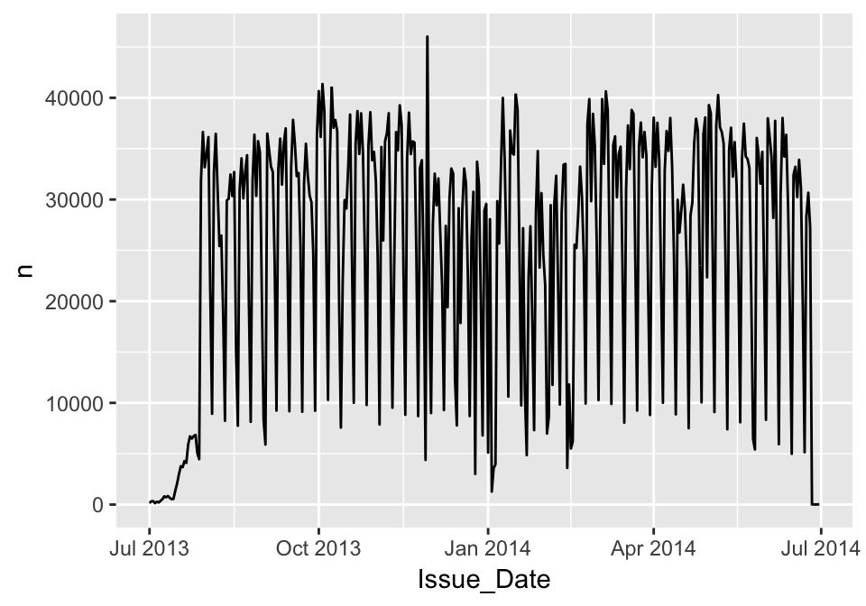

```r
nyc %>%
  group_by(Issue_Date) %>%
  summarize(n = n()) %>%
  ggplot(aes(x = Issue_Date, y = n)) +
    geom_line() +
    xlim(mdy("7/1/2013"), mdy("6/30/2014"))
```

## Create an SQLite database

Import the `nyc` data set into the SQLite database:

```r
library("DBI")
library("RSQLite")
library("tidyverse")
if (Sys.info()[["sysname"]] == "Linux") {
  db <- dbConnect(RSQLite::SQLite(),
                  dbname = "/home/m280-data/nyc_parking/NYParkingViolations.sqlite")
} else if (Sys.info()[["sysname"]] == "Darwin") {
  db <- dbConnect(RSQLite::SQLite(),
                  dbname = "./NYParkingViolations.sqlite")
}
dbWriteTable(db, "nyc", nyc, overwrite = TRUE)
dbListTables(db)
```

```
## [1] "nyc"
```

```r
dbDisconnect(db)
```

You can create a symbolic link to the database file by Bash command

```bash
ln -sf /home/m280-data/nyc_parking/NYParkingViolations.sqlite NYParkingViolations.sqlite
```

Size of the database file

```bash
ls -l NYParkingViolations.sqlite
```

```
## -rw-r--r--  1 huazhou  staff  729309184 Feb 19 20:43 NYParkingViolations.sqlite
```

## Read data from database

Connect to table in database:

```r
db <- dbConnect(RSQLite::SQLite(), dbname = "./NYParkingViolations.sqlite")
dbListTables(db)
```

```
## [1] "nyc"
```

```r
nyc_sql <- dplyr::tbl(db, "nyc")
str(nyc_sql)
```

```
## List of 2
##  $ src:List of 2
##   ..$ con  :Formal class 'SQLiteConnection' [package "RSQLite"] with 6 slots
##   .. .. ..@ ptr                :<externalptr>
##   .. .. ..@ dbname             : chr "/Users/huazhou/Documents/github.com/Hua-Zhou.github.io/teaching/biostatm280-2018winter/slides/11-dbplyr/NYParki"| __truncated__
##   .. .. ..@ loadable.extensions: logi TRUE
##   .. .. ..@ flags              : int 70
##   .. .. ..@ vfs                : chr ""
##   .. .. ..@ ref                :<environment: 0x7fc41647f6b0>
##   ..$ disco: NULL
##   ..- attr(*, "class")= chr [1:3] "src_dbi" "src_sql" "src"
##  $ ops:List of 2
##   ..$ x   :Classes 'ident', 'character'  chr "nyc"
##   ..$ vars: chr [1:18] "Registration_State" "Plate_Type" "Issue_Date" "Violation_Code" ...
##   ..- attr(*, "class")= chr [1:3] "op_base_remote" "op_base" "op"
##  - attr(*, "class")= chr [1:4] "tbl_dbi" "tbl_sql" "tbl_lazy" "tbl"
```

```r
nyc_sql %>% print(width = Inf)
```

```
## # Source:   table<nyc> [?? x 18]
## # Database: sqlite 3.19.3
## #   [/Users/huazhou/Documents/github.com/Hua-Zhou.github.io/teaching/biostatm280-2018winter/slides/11-dbplyr/NYParkingViolations.sqlite]
##    Registration_State Plate_Type Issue_Date Violation_Code
##    <chr>              <chr>           <dbl>          <int>
##  1 NY                 PAS             15915             94
##  2 NY                 COM             15712             19
##  3 NY                 COM             15706             46
##  4 IL                 PAS             15706             78
##  5 NJ                 PAS             15706             46
##  6 NY                 PAS             15706             46
##  7 NY                 COM             15706             78
##  8 NY                 COM             15706             46
##  9 OK                 PAS             15706             47
## 10 NY                 COM             15706             45
```

[output cut: 49 more lines]

## Use dplyr with SQLite

```r
addr <- nyc_sql %>%
  select(Issue_Date, Issuing_Agency, Violation_Precinct, Number, Street) %>%
  filter(Violation_Precinct >= 1, Violation_Precinct <= 34)
addr
```

```
## # Source:   lazy query [?? x 5]
## # Database: sqlite 3.19.3
## #   [/Users/huazhou/Documents/github.com/Hua-Zhou.github.io/teaching/biostatm280-2018winter/slides/11-dbplyr/NYParkingViolations.sqlite]
##    Issue_Date Issuing_Agency Violation_Precinct Number  Street
##         <dbl> <chr>                       <int> <chr>   <chr>
##  1      15706 P                              25 2       W 120TH ST
##  2      15706 P                              13 456     3RD AVE
##  3      15706 P                              26 44      MORNINGSIDE DR
##  4      15706 X                              14 8       PENN PLAZA
##  5      15706 P                              25 2123    MADISON AVE
##  6      15706 P                              18 413     48 TH ST
##  7      15706 P                              12 630     LEXINGTON AVE
##  8      15706 P                              25 219     E 121 ST
##  9      15706 P                              26 1420    AMSTERDAM AVE
## 10      15706 P                              26 488-490 ST NICHOLAS AVE
## # ... with more rows
```

## SQL query

```r
class(addr)
```

```
## [1] "tbl_dbi"  "tbl_sql"  "tbl_lazy" "tbl"
```

```r
show_query(addr)
```

```
## <SQL>
## SELECT *
## FROM (SELECT `Issue_Date`, `Issuing_Agency`, `Violation_Precinct`, `Number`, `Street`
## FROM `nyc`)
## WHERE ((`Violation_Precinct` >= 1.0) AND (`Violation_Precinct` <= 34.0))
```

## Mutate and summarise

```r
addr %>% mutate(address = paste(Number, Street))
```

```
## # Source:   lazy query [?? x 6]
## # Database: sqlite 3.19.3
## #   [/Users/huazhou/Documents/github.com/Hua-Zhou.github.io/teaching/biostatm280-2018winter/slides/11-dbplyr/NYParkingViolations.sqlite]
##    Issue_Date Issuing_Agency Violation_Precinct Number  Street   address
##         <dbl> <chr>                       <int> <chr>   <chr>    <chr>
##  1      15706 P                              25 2       W 120TH… 2 W 120T…
##  2      15706 P                              13 456     3RD AVE  456 3RD …
##  3      15706 P                              26 44      MORNING… 44 MORNI…
##  4      15706 X                              14 8       PENN PL… 8 PENN P…
##  5      15706 P                              25 2123    MADISON… 2123 MAD…
##  6      15706 P                              18 413     48 TH ST 413 48 T…
##  7      15706 P                              12 630     LEXINGT… 630 LEXI…
##  8      15706 P                              25 219     E 121 ST 219 E 12…
##  9      15706 P                              26 1420    AMSTERD… 1420 AMS…
## 10      15706 P                              26 488-490 ST NICH… 488-490 …
## # ... with more rows
```

```r
addr %>% summarize(mean = mean(Violation_Precinct, na.rm = TRUE))
```

```
## # Source:   lazy query [?? x 1]
## # Database: sqlite 3.19.3
## #   [/Users/huazhou/Documents/github.com/Hua-Zhou.github.io/teaching/biostatm280-2018winter/slides/11-dbplyr/NYParkingViolations.sqlite]
##    mean
##   <dbl>
## 1  16.1
```

## SQL grouping

```r
addr %>%
  group_by(Issuing_Agency, Violation_Precinct) %>%
  summarize(n = n())
```

```
## # Source:   lazy query [?? x 3]
## # Database: sqlite 3.19.3
## #   [/Users/huazhou/Documents/github.com/Hua-Zhou.github.io/teaching/biostatm280-2018winter/slides/11-dbplyr/NYParkingViolations.sqlite]
## # Groups:   Issuing_Agency
##    Issuing_Agency Violation_Precinct     n
##    <chr>                       <int> <int>
##  1 A                               1    13
##  2 A                               7     1
##  3 A                              10    24
##  4 A                              11     1
##  5 A                              14    47
##  6 A                              33    11
##  7 B                              25     2
##  8 C                               5    73
##  9 C                              13     7
## 10 D                               1     1
## # ... with more rows
```

## SQL query

```r
addr %>%
  group_by(Issuing_Agency, Violation_Precinct) %>%
  summarize(n = n()) %>%
  show_query()
```

```
## <SQL>
## SELECT `Issuing_Agency`, `Violation_Precinct`, COUNT() AS `n`
## FROM (SELECT `Issue_Date`, `Issuing_Agency`, `Violation_Precinct`, `Number`, `Street`
## FROM `nyc`)
## WHERE ((`Violation_Precinct` >= 1.0) AND (`Violation_Precinct` <= 34.0))
## GROUP BY `Issuing_Agency`, `Violation_Precinct`
```

## SQL translation

dbplyr package (a dplyr backend for databases) has a function, `translate_sql`, that lets you experiment with how R functions are translated to SQL:

```r
library("dbplyr")
translate_sql(x == 1 & (y < 2 | z > 3))
```

```
## <SQL> "x" = 1.0 AND ("y" < 2.0 OR "z" > 3.0)
```

```r
translate_sql(x ^ 2 < 10)
```

```
## <SQL> POWER("x", 2.0) < 10.0
```

```r
translate_sql(x %% 2 == 10)
```

```
## <SQL> "x" % 2.0 = 10.0
```

```r
translate_sql(paste(x, y))
```

```
## <SQL> PASTE("x", "y")
```

```r
translate_sql(mean(x))
```

```
## <SQL> avg("x") OVER ()
```

```r
translate_sql(mean(x, na.rm = TRUE))
```

```
## <SQL> avg("x") OVER ()
```

## Timings

dplyr using tibble:

```r
system.time(
  nyc %>%
    select(Issue_Date, Issuing_Agency, Violation_Precinct, Number, Street) %>%
    filter(Violation_Precinct >=1, Violation_Precinct <= 34) %>%
    group_by(Issuing_Agency, Violation_Precinct) %>%
    summarize(n = n())
)
```

```
##    user  system elapsed
##   0.383   0.091   0.479
```

dplyr using SQLite:

```r
system.time(
  nyc_sql %>%
    select(Issue_Date, Issuing_Agency, Violation_Precinct, Number, Street) %>%
    filter(Violation_Precinct >=1, Violation_Precinct <= 34) %>%
    group_by(Issuing_Agency, Violation_Precinct) %>%
    summarize(n = n())
)
```

```
##    user  system elapsed
##   0.016   0.000   0.017
```

`nyc_sql` was 30x times faster than `nyc`, but the former is disk based while the latter is in memory. Why is the discrepancy?

## Laziness

dplyr/dbplyr uses lazy evaluation as much as possible, particularly when working with non-local backends.

- When building a query, we don’t want the entire table, often we want just enough to check if our query is working.
- Since we would prefer to run one complex query over many simple queries, laziness allows for verbs to be strung together.
- Therefore, by default dplyr
  - won’t connect and query the database until absolutely necessary (e.g. show output),
  - and unless explicitly told to, will only query a handful of rows to give a sense of what the result will look like

```r
nyc_sql %>%
  select(Issue_Date, Issuing_Agency, Violation_Precinct, Number, Street) %>%
  filter(Violation_Precinct >=1, Violation_Precinct <= 34) %>%
  group_by(Issuing_Agency, Violation_Precinct) %>%
  summarize(n = n())
```

```
## # Source:   lazy query [?? x 3]
## # Database: sqlite 3.19.3
## #   [/Users/huazhou/Documents/github.com/Hua-Zhou.github.io/teaching/biostatm280-2018winter/slides/11-dbplyr/NYParkingViolations.sqlite]
## # Groups:   Issuing_Agency
##    Issuing_Agency Violation_Precinct     n
##    <chr>                       <int> <int>
##  1 A                               1    13
##  2 A                               7     1
##  3 A                              10    24
##  4 A                              11     1
##  5 A                              14    47
##  6 A                              33    11
##  7 B                              25     2
##  8 C                               5    73
##  9 C                              13     7
## 10 D                               1     1
## # ... with more rows
```

## Full query

To force a full query and return a complete table it is necessary to use the `collect` function.

```r
system.time(
  nyc_sql %>%
    select(Issue_Date, Issuing_Agency, Violation_Precinct, Number, Street) %>%
    filter(Violation_Precinct >=1, Violation_Precinct <= 34) %>%
    group_by(Issuing_Agency, Violation_Precinct) %>%
    summarize(n = n()) %>%
    collect()
)
```

```
##    user  system elapsed
##   3.166   0.341   3.544
```

## Plotting

### Bar plot

Suppose we want the bar plot of number of tickets on each weekday. We encounter error with the usual ggplot2 command:

```r
nyc_sql %>%
  ggplot() +
    geom_bar(aes(x = Issue_WDay))
```

```
## Error: ggplot2 doesn't know how to deal with data of class tbl_dbi/tbl_sql/tbl_lazy/tbl
```

This is becasue ggplot2 needs to compute the count per category by going through all the rows. But here `nyc_sql` is just a pointer to the SQLite table. We have to use the **transform in database, plot in R** strategy.

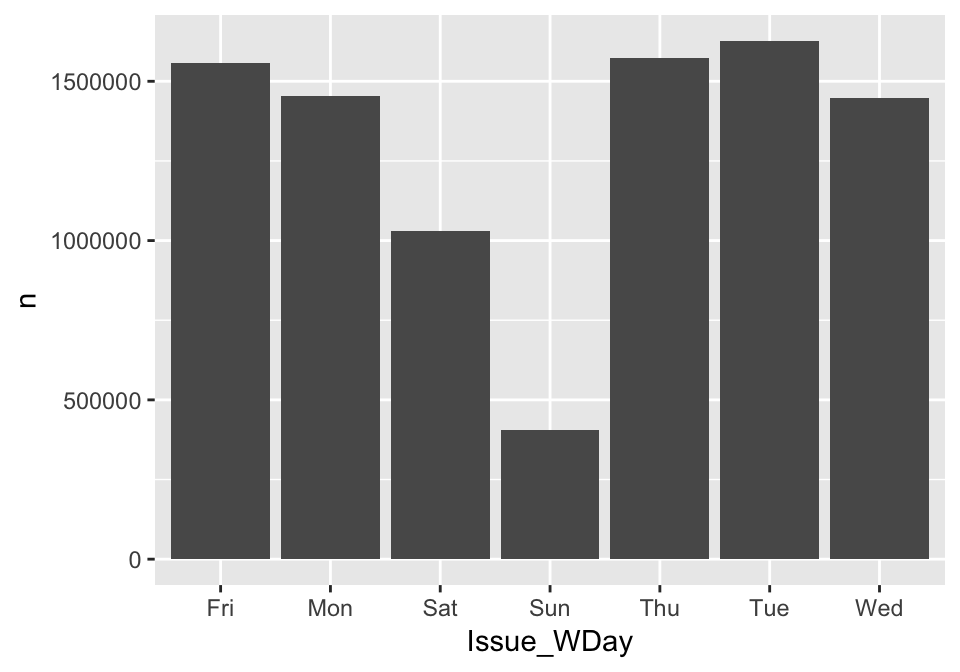

```r
nyc_sql %>%
  group_by(Issue_WDay) %>%
  count() %>%
  collect() %>%
  ggplot() +
    geom_col(aes(x = Issue_WDay, y = n))
```

### Other plots

For example of making histogram and raster plot, read tutorial https://db.rstudio.com/best-practices/visualization/.

## Close connection to database

```r
dbDisconnect(db)
```